# Estudio de circulación vehicular en Montevideo: febrero-marzo 2021

22/7/2021

## Introducción

- El objetivo general de este trabajo se basa en un estudio de las velocidades de los vehículos que circulan en Montevideo en conjunto con la cantidad de vehículos que se logran capturar a partir del Centro de Gestión de Movilidad (CGM).
- En particular surge el interés de estudiar geográficamente los volúmenes de circulación y su asociación con las velocidades registradas.
- Estudiar aquellos puntos con mayores registros de velocidad y aquellos con menores registros a fin de capturar la potencial necesidad de regulación en ciertos puntos de la capital.

## Estructura de los datos

- Datos brindados por el CGM de la IM.
- Base de datos referente a velocidad y volumen de circulación de vehículos registrados por las cámaras de CGM con día y hora de lo acontecido.
- 7.623.354 observaciones para los meses de Febrero y Marzo
- Los datos vinculados a la velocidad de circulación cuentan con 10 variables mientras que los datos de conteo vehicular cuentan con 11 observaciones.
- Variables numéricas, caracteres, fecha y hora.
- Se crean tres variables categóricas.

## Correlaciones y densidades

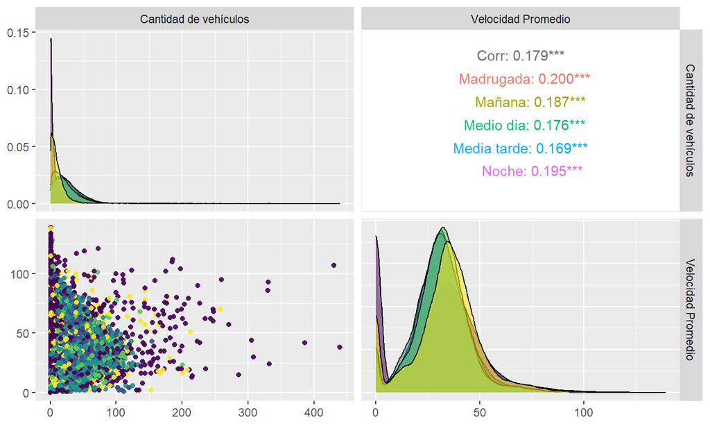

## Distribución del volumen y la velocidad promedio de los vehículos discriminando por CCZ

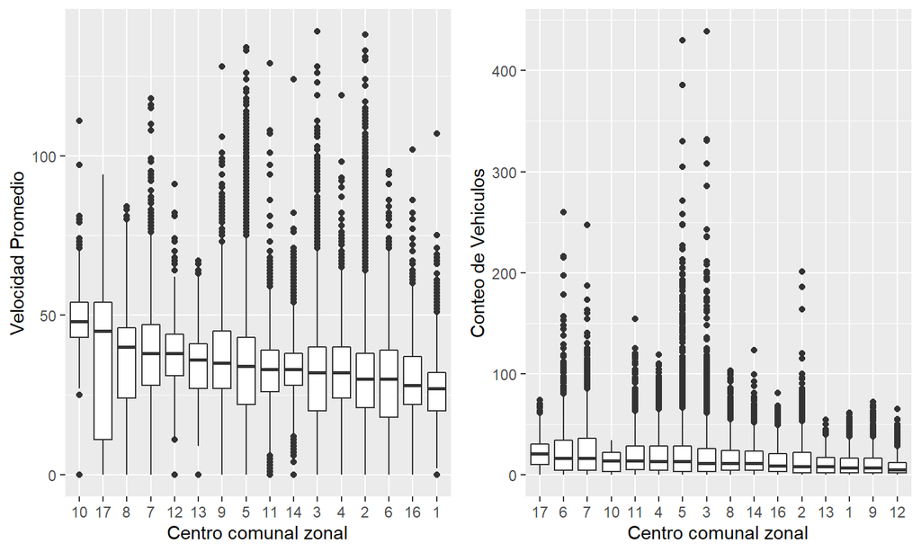